# Gresham Lab Floww Cytometry Single Timepoint Analysis

```r
xyplot(FL1.A ~ FSC.A, data=dataLGCLTransform, smooth=F,  stat=T, pos=0.5, abs=T, xlim=c(4,8), sampleNames(filteredData))
```

[output not shown]

```r
xyplot(SSC.A ~ FSC.A, data=dataLGCLTransform, smooth=F,  stat=T, pos=0.5, abs=T, xlim=c(4,8), ylim=c(4,8), sampleNames(filteredData))
```

[output not shown]

```r
#Transfer data into a dataframe
#Move filtered data into a dataframe
filtered.data <- sample.param
if(extract.FSC_A == "Yes"){filtered.data<-cbind(filtered.data, FSC.A=NA)}
if(extract.SSC_A == "Yes"){filtered.data<-cbind(filtered.data, SSC.A=NA)}
if(extract.FL1_A == "Yes"){filtered.data<-cbind(filtered.data, FL1.A=NA)}
if(extract.FL2_A == "Yes"){filtered.data<-cbind(filtered.data, FL2.A=NA)}
if(extract.FL3_A == "Yes"){filtered.data<-cbind(filtered.data, FL3.A=NA)}
if(extract.FL4_A == "Yes"){filtered.data<-cbind(filtered.data, FL4.A=NA)}
if(extract.FSC_H == "Yes"){filtered.data<-cbind(filtered.data, FSC.H=NA)}
if(extract.SSC_H == "Yes"){filtered.data<-cbind(filtered.data, SSC.H=NA)}
if(extract.FL1_H == "Yes"){filtered.data<-cbind(filtered.data, FL1.H=NA)}
if(extract.FL2_H == "Yes"){filtered.data<-cbind(filtered.data, FL2.H=NA)}
if(extract.FL3_H == "Yes"){filtered.data<-cbind(filtered.data, FL3.H=NA)}
if(extract.FL4_H == "Yes"){filtered.data<-cbind(filtered.data, FL4.H=NA)}
if(extract.Width == "Yes"){filtered.data<-cbind(filtered.data, Width=NA)}
if(extract.Time == "Yes"){filtered.data<-cbind(filtered.data, Time=NA)}
for(i in 1:length(filteredData)){
  sample <- sampleNames(filteredData)[i]
  well <- as.character(pData(filteredData)$Well[i])
  strain <- as.character(pData(filteredData)$Strain[i])
  genotype <- as.character(pData(filteredData)$Genotype[i])
  ploidy <- as.character(pData(filteredData)$Ploidy[i])
  media <- as.character(pData(filteredData)$Media[i])
  exp <- as.character(pData(filteredData)$Experiment[i])
  if(extract.FSC_A == "Yes"){fsc.a <- exprs(filteredData[[i,1]])}
  if(extract.SSC_A == "Yes"){ssc.a <- exprs(filteredData[[i,2]])}
  if(extract.FL1_A == "Yes"){fl1.a <- exprs(filteredData[[i,3]])}
  if(extract.FL2_A == "Yes"){fl2.a <- exprs(filteredData[[i,4]])}
  if(extract.FL3_A == "Yes"){fl3.a <- exprs(filteredData[[i,5]])}
  if(extract.FL4_A == "Yes"){fl4.a <- exprs(filteredData[[i,6]])}
  if(extract.FSC_H == "Yes"){fsc.h <- exprs(filteredData[[i,7]])}
  if(extract.SSC_H == "Yes"){ssc.h <- exprs(filteredData[[i,8]])}
  if(extract.FL1_H == "Yes"){fl1.h <- exprs(filteredData[[i,9]])}
  if(extract.FL2_H == "Yes"){fl2.h <- exprs(filteredData[[i,10]])}
  if(extract.FL3_H == "Yes"){fl3.h <- exprs(filteredData[[i,11]])}
  if(extract.FL4_H == "Yes"){fl4.h <- exprs(filteredData[[i,12]])}
  if(extract.Width == "Yes"){width <- exprs(filteredData[[i,11]])}
  if(extract.Time == "Yes"){time <- exprs(filteredData[[i,12]])}
  filtered.data <- rbind(filtered.data, cbind(SAMPLE=sample,WELL=well,STRAIN=strain,GENOTYPE=genotype,PLOIDY=ploidy,MEDIA=media,EXPERIMENT=exp,
                    if(extract.FSC_A == "Yes"){FSC.A=fsc.a},
                    if(extract.SSC_A == "Yes"){SSC.A=ssc.a},
                    if(extract.FL1_A == "Yes"){FL1.A=fl1.a},
                    if(extract.FL2_A == "Yes"){FL2.A=fl2.a},
                    if(extract.FL3_A == "Yes"){FL3.A=fl3.a},
                    if(extract.FL4_A == "Yes"){FL4.A=fl4.a},
                    if(extract.FSC_H == "Yes"){FSC.H=fsc.h},
                    if(extract.SSC_H == "Yes"){SSC.H=ssc.h},
                    if(extract.FL1_H == "Yes"){FL1.H=fl1.h},
                    if(extract.FL2_H == "Yes"){FL2.H=fl2.h},
                    if(extract.FL3_H == "Yes"){FL3.H=fl3.h},
                    if(extract.FL4_H == "Yes"){FL4.H=fl4.h},
                    if(extract.Width == "Yes"){Width=width},
                    if(extract.Time == "Yes"){Time=time}))
}
 #Cleans up DataFrames
  filtered.data<-filtered.data[2:nrow(filtered.data),]
  if(extract.FSC_A == "Yes"){filtered.data$FSC.A<-as.numeric(filtered.data$FSC.A)}
  if(extract.SSC_A == "Yes"){filtered.data$SSC.A<-as.numeric(filtered.data$SSC.A)}
  if(extract.FL1_A == "Yes"){filtered.data$FL1.A<-as.numeric(filtered.data$FL1.A)}
  if(extract.FL2_A == "Yes"){filtered.data$FL2.A<-as.numeric(filtered.data$FL2.A)}
  if(extract.FL3_A == "Yes"){filtered.data$FL3.A<-as.numeric(filtered.data$FL3.A)}
  if(extract.FL4_A == "Yes"){filtered.data$FL4.A<-as.numeric(filtered.data$FL4.A)}
  if(extract.FSC_H == "Yes"){filtered.data$FSC.A<-as.numeric(filtered.data$FSC.A)}
  if(extract.SSC_H == "Yes"){filtered.data$SSC.A<-as.numeric(filtered.data$SSC.A)}
  if(extract.FL1_H == "Yes"){filtered.data$FL1.A<-as.numeric(filtered.data$FL1.A)}
  if(extract.FL2_H == "Yes"){filtered.data$FL2.A<-as.numeric(filtered.data$FL2.A)}
  if(extract.FL3_H == "Yes"){filtered.data$FL3.A<-as.numeric(filtered.data$FL3.A)}
  if(extract.FL4_H == "Yes"){filtered.data$FL4.A<-as.numeric(filtered.data$FL4.A)}
  if(extract.Width == "Yes"){filtered.data$Width<-as.numeric(filtered.data$Width)}
  if(extract.Time == "Yes"){filtered.data$Time<-as.numeric(filtered.data$Time)}
```

```r
stats.data <- cbind(sample.param,COUNT=NA,FSC_MEDIAN=NA,FSC_MEAN=NA,FSC_SD=NA,FL1_MEDIAN=NA,FL1_MEAN=NA,FL1_SD=NA,NORMALIZED_GFP_MEDIAN=NA,NORMALIZED_GFP_MEAN=NA,NORMALIZED_GFP_SD=NA)
 for(i in 1:length(filteredData)){
  sample <- sampleNames(filteredData)[i]
  well <- as.character(pData(filteredData)$Well[i])
  strain <- as.character(pData(filteredData)$Strain[i])
  genotype <- as.character(pData(filteredData)$Genotype[i])
  ploidy <- as.character(pData(filteredData)$Ploidy[i])
  media <- as.character(pData(filteredData)$Media[i])
  exp <- as.character(pData(filteredData)$Experiment[i])
  if(extract.FSC_A == "Yes"){fsc.a <- exprs(filteredData[[i,1]])}
  if(extract.SSC_A == "Yes"){ssc.a <- exprs(filteredData[[i,2]])}
  if(extract.FL1_A == "Yes"){fl1.a <- exprs(filteredData[[i,3]])}
  if(extract.FL2_A == "Yes"){fl2.a <- exprs(filteredData[[i,4]])}
  if(extract.FL3_A == "Yes"){fl3.a <- exprs(filteredData[[i,5]])}
  if(extract.FL4_A == "Yes"){fl4.a <- exprs(filteredData[[i,6]])}
  if(extract.FSC_H == "Yes"){fsc.h <- exprs(filteredData[[i,7]])}
  if(extract.SSC_H == "Yes"){ssc.h <- exprs(filteredData[[i,8]])}
  if(extract.FL1_H == "Yes"){fl1.h <- exprs(filteredData[[i,9]])}
  if(extract.FL2_H == "Yes"){fl2.h <- exprs(filteredData[[i,10]])}
  if(extract.FL3_H == "Yes"){fl3.h <- exprs(filteredData[[i,11]])}
  if(extract.FL4_H == "Yes"){fl4.h <- exprs(filteredData[[i,12]])}
  if(extract.Width == "Yes"){width <- exprs(filteredData[[i,11]])}
  if(extract.Time == "Yes"){time <- exprs(filteredData[[i,12]])}

  stats.data<-(rbind(stats.data,cbind(SAMPLE=sample,WELL=well,STRAIN=strain,GENOTYPE=genotype,PLOIDY=ploidy,MEDIA=media,EXPERIMENT=exp,COUNT=length(fsc.a),FSC_MEDIAN=median(fsc.a),FSC_MEAN=mean(fsc.a),FSC_SD=sd(fsc.a),FL1_MEDIAN=median(fl1.a),FL1_MEAN=mean(fl1.a),FL1_SD=sd(fl1.a),NORMALIZED_GFP_MEDIAN=median(fl1.a/fsc.a),NORMALIZED_GFP_MEAN=mean(fl1.a/fsc.a),NORMALIZED_GFP_SD=sd(fl1.a/fsc.a))))
}
stats.data<-stats.data[2:nrow(stats.data),]
stats.data$COUNT<-as.numeric(stats.data$COUNT)
stats.data$FSC_MEDIAN<-as.numeric(stats.data$FSC_MEDIAN)
stats.data$FSC_MEAN<-as.numeric(stats.data$FSC_MEAN)
stats.data$FSC_SD<-as.numeric(stats.data$FSC_SD)
stats.data$FL1_MEDIAN<-as.numeric(stats.data$FL1_MEDIAN)
stats.data$FL1_MEAN<-as.numeric(stats.data$FL1_MEAN)
stats.data$FL1_SD<-as.numeric(stats.data$FL1_SD)
stats.data$NORMALIZED_GFP_MEDIAN<-as.numeric(stats.data$NORMALIZED_GFP_MEDIAN)
stats.data$NORMALIZED_GFP_MEAN<-as.numeric(stats.data$NORMALIZED_GFP_MEAN)
stats.data$NORMALIZED_GFP_SD<-as.numeric(stats.data$NORMALIZED_GFP_SD)
```

# Plots

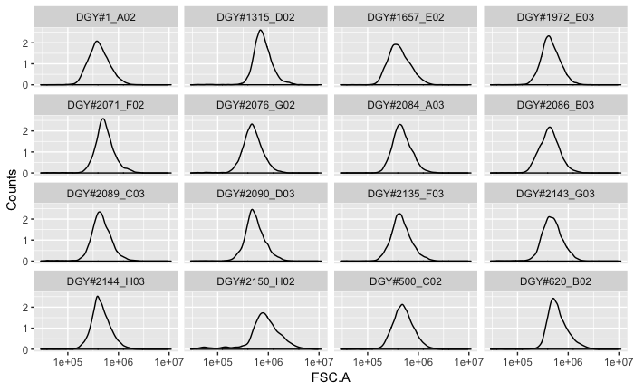

```r
ggplot(filtered.data)+
      geom_density(aes(x = FSC.A), colour = "black")+
      theme()+
      labs(y = "Counts", x = "FSC.A") +
      scale_x_log10()+
      facet_wrap('SAMPLE')
```

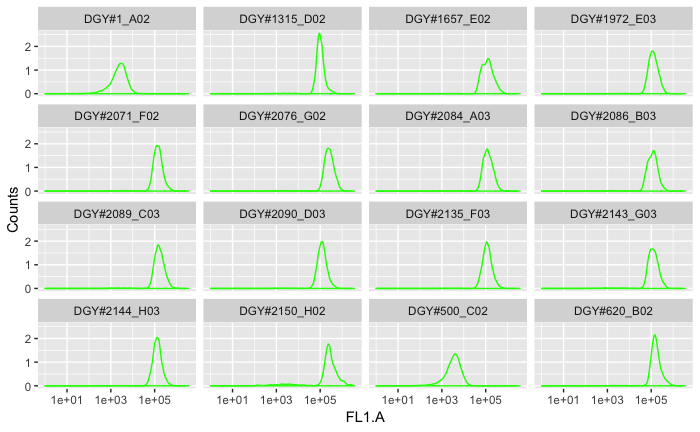

```r
ggplot(filtered.data )+
      geom_density(aes(x = FL1.A), colour = "green")+
      theme()+
      labs(y = "Counts", x = "FL1.A") +
      scale_x_log10()+
      facet_wrap('SAMPLE')
```

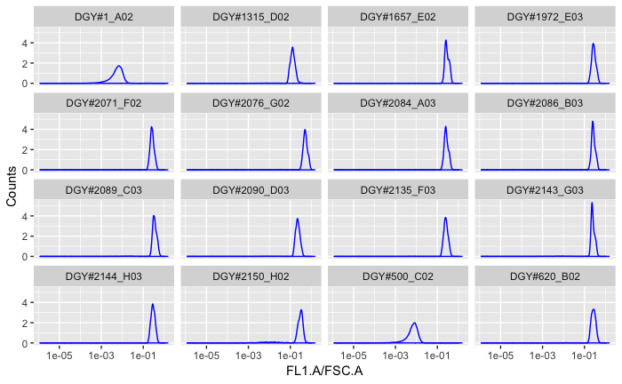

```r
ggplot(filtered.data )+
      geom_density(aes(x = FL1.A/FSC.A), colour = "blue")+
      theme()+
      labs(y = "Counts",x = "FL1.A/FSC.A") +
      scale_x_log10()+
      facet_wrap('SAMPLE')
```

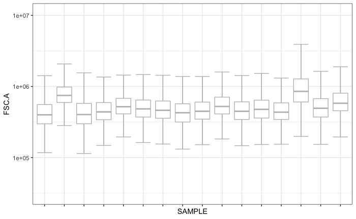

```r
ggplot(filtered.data, aes(SAMPLE,FSC.A)) +
    theme_bw() +
    theme(axis.text.x = element_text(angle = 90,vjust=0.5,hjust = 1, size = 6)) +
    stat_boxplot(geom ='errorbar', colour = "grey") +
    geom_boxplot(outlier.shape = NA, colour = "grey") +
    #geom_hline(yintercept=haploid.fsc, lty=2, colour = "black") +
    #geom_hline(yintercept=diploid.fsc, lty=2, colour = "blue") +
    scale_y_log10()+
    scale_x_discrete(labels=levels(filtered.data$SAMPLE))
```

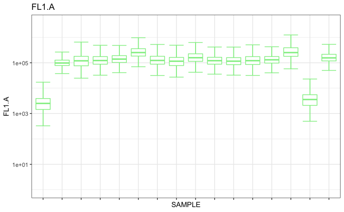

```r
ggplot(filtered.data, aes(SAMPLE,FL1.A)) +
    theme_bw() +
    theme(axis.text.x = element_text(angle = 90,vjust=0.5,hjust = 1, size = 6)) +
    stat_boxplot(geom ='errorbar', colour = "lightgreen") +
    geom_boxplot(outlier.shape = NA, colour = "lightgreen") +
    #geom_hline(yintercept=gfp.bg, lty=2, colour = "yellow") +
    #geom_hline(yintercept=gfp.wt, lty=2, colour = "green") +
    labs(title= paste("FL1.A", sep="")) +
    scale_y_log10()+
    scale_x_discrete(labels=levels(filtered.data$SAMPLE))
```

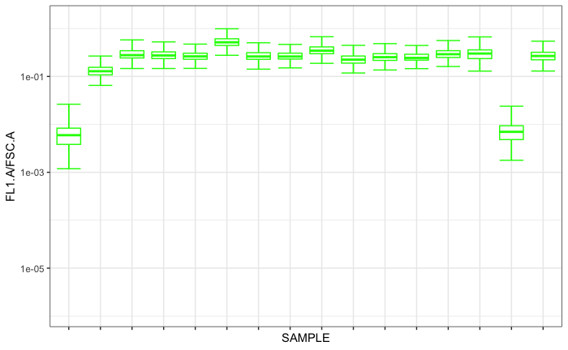

```r
ggplot(filtered.data, aes(SAMPLE,FL1.A/FSC.A)) +
    theme_bw() +
    theme(axis.text.x = element_text(angle = 90,vjust=0.5,hjust = 1, size = 6)) +
    stat_boxplot(geom ='errorbar', colour = "green") +
    geom_boxplot(outlier.shape = NA, colour = "green") +
    #geom_hline(yintercept=gfp.norm, lty=2, colour = "blue") +
    scale_y_log10()+
    scale_x_discrete(labels=levels(filtered.data$SAMPLE))
```

```r
###FL1###
baseline.FL1 <- stats.data$FL1_MEDIAN[2] #MUST REPLACE WITH YOUR FL1 ChannelCONTROL!!
```

[output not shown]